# Final project

### **Special requests**

We would like to visualize how special requests relate to reservation status in the different hotels

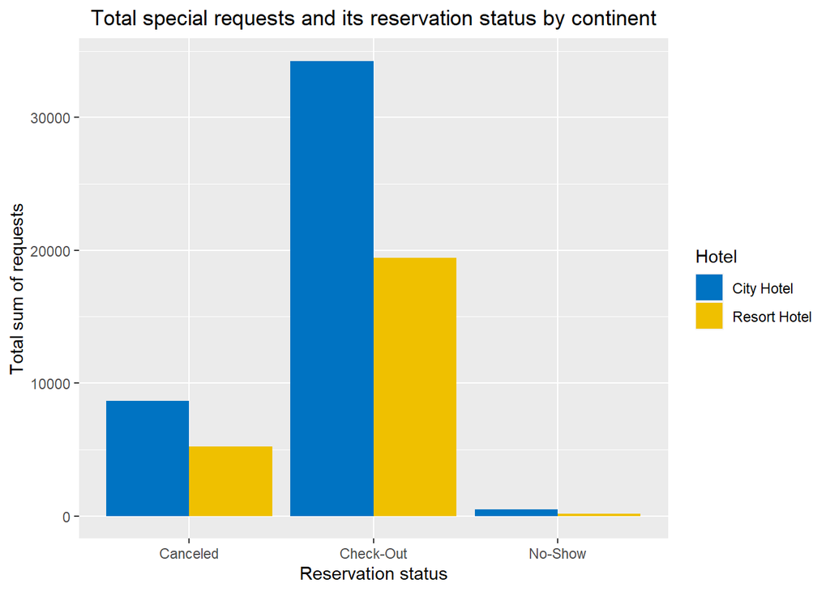

```r
special_requests <- hotel_book_fac %>%
  group_by(hotel, reservation_status) %>%
  summarize(spec_re_sum =
              sum(total_of_special_requests)) %>%
  arrange(desc(spec_re_sum))

view(special_requests)

# Plot
ggplot(special_requests, aes(x = reservation_status, y= spec_re_sum, fill = hotel)) +
  geom_col(position = "dodge") +
  scale_fill_jco() +
  labs(title = "Total special requests and its reservation status by continent",
       x= "Reservation status",
       y= "Total sum of requests",
       fill = "Hotel") +
  theme(plot.title = element_text(hjust = 0.5))
```

Based on the plot we can visualize that when there are special requests clients are more likely to check out, however a great number of special requests were made and the reservation was still cancelled. Most of the reservations and cancellations are done in City Hotel.

### **Total of check-out clients**

The dataset contains reservations that were cancelled and clients who did not show up. We want to visualize the total number of clients (adult, children and babies) that checkout in each hotel.

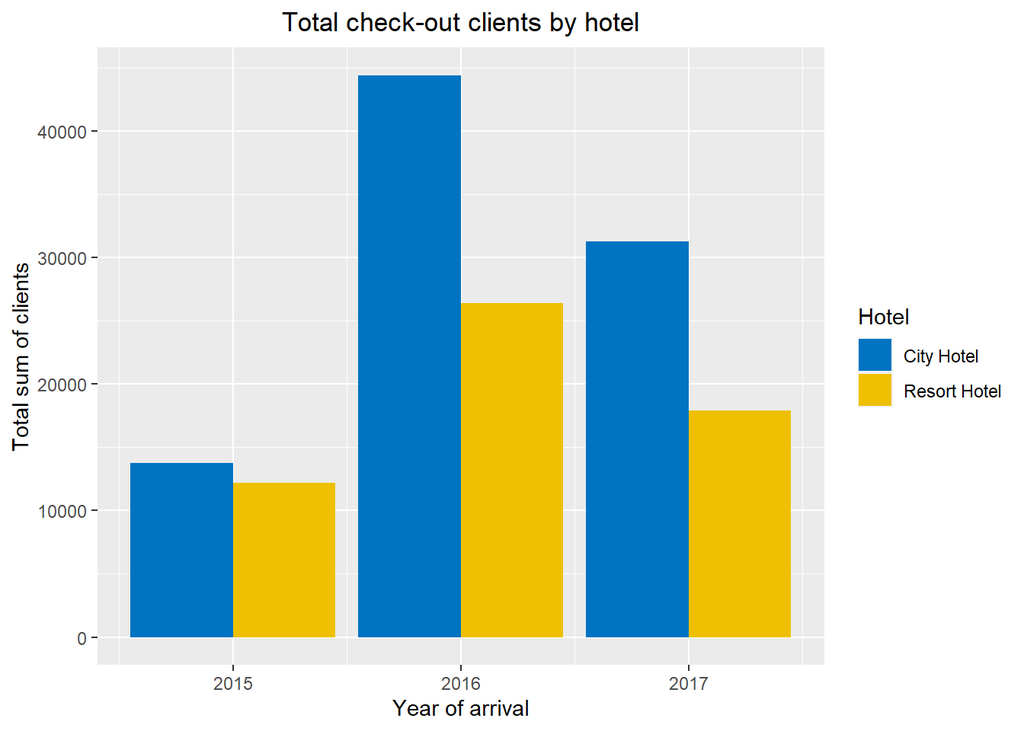

```r
hotel_booking2 <- hotel_book_fac %>%
  group_by(hotel,reservation_status, arrival_date_year) %>%
  summarize(tot_clients = (sum(adults, children, babies, na.rm = TRUE))) %>%
  filter(reservation_status == "Check-Out") %>%
  ggplot(aes(x = arrival_date_year, y = tot_clients, fill = hotel)) +
  geom_col(position = "dodge") +
  scale_fill_jco() +
  labs(title = "Total check-out clients by hotel",
       x= "Year of arrival",
       y= "Total sum of clients",
       fill = "Hotel") +
  theme(plot.title = element_text(hjust = 0.5))

print(hotel_booking2)
```

Based on the graph we can visualize that City hotel had more clients every year than Resort Hotel

### **Reservation status**

We want to visualize how different variables relate to reservations status

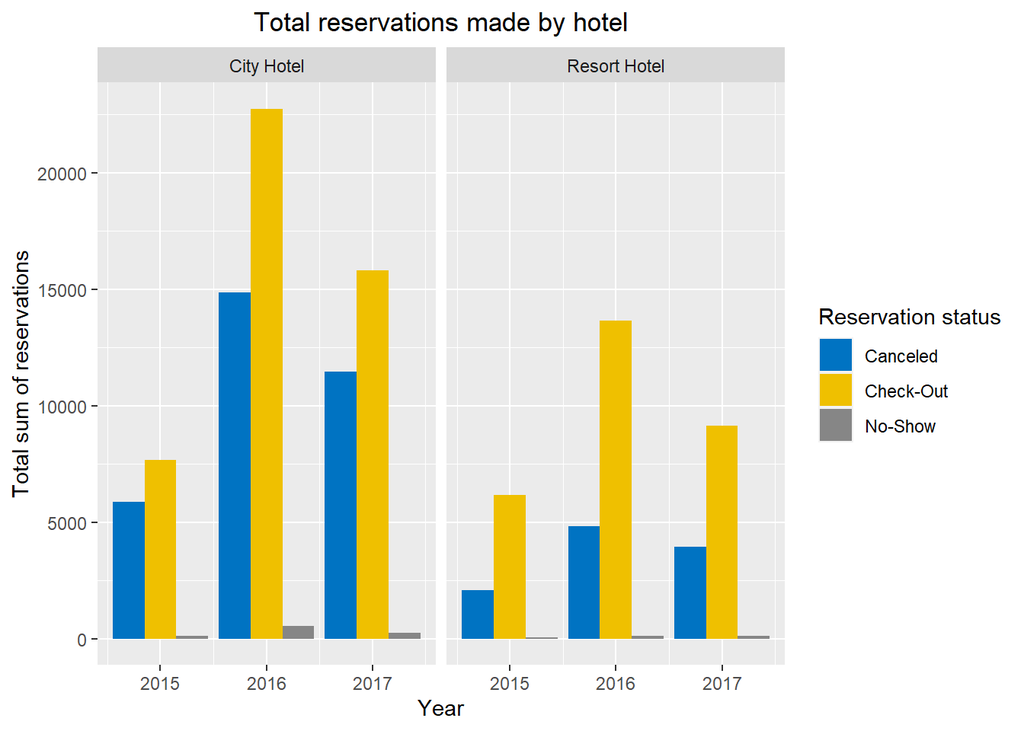

```r
# We want to visualize the total sum of reservations and its status made each year in each hotel

hotel_booking3 <- hotel_book_fac %>%
  group_by(hotel,reservation_status, arrival_date_year) %>%
  ggplot(aes(x = arrival_date_year, fill = reservation_status)) +
  geom_bar(position = "dodge") +
  facet_wrap(~ hotel) +
  scale_fill_jco() +
  labs(title = "Total reservations made by hotel",
       x= "Year",
       y= "Total sum of reservations",
       fill = "Reservation status") +
  theme(plot.title = element_text(hjust = 0.5))

print(hotel_booking3)
```

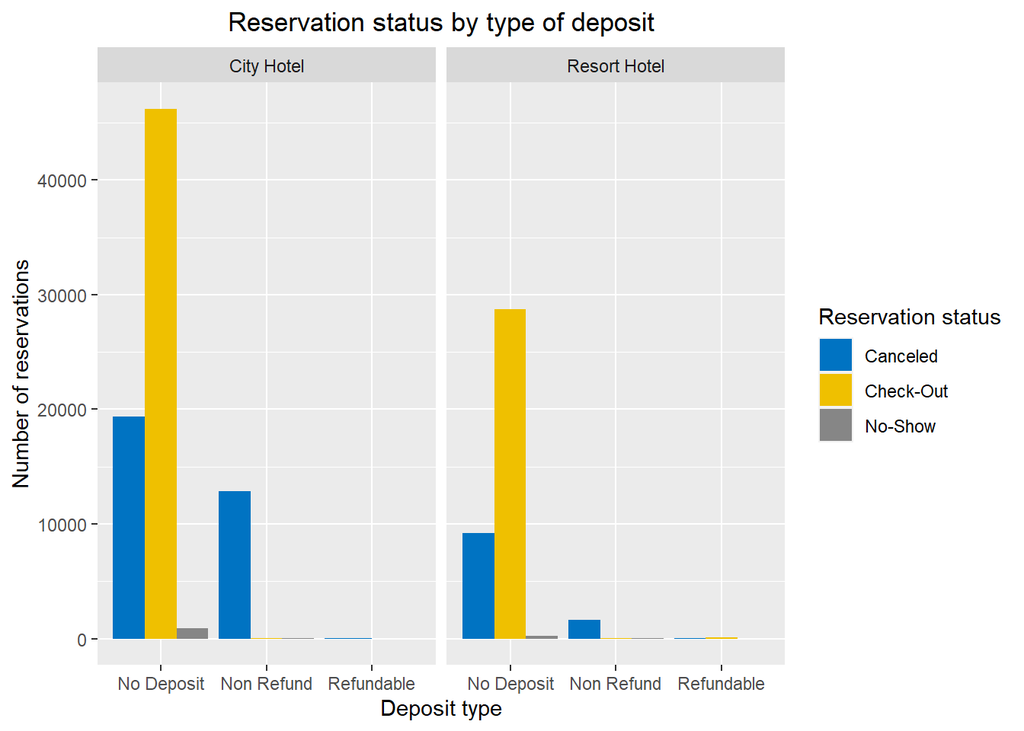

```r
# Based on the plot City hotel has more reservations but also more cancellations. 2016 was the year with the highest peak on reservations for both hotels.

# We also want to visualize the reservation status by deposit type
ggplot(hotel_book_fac, aes(x = deposit_type, fill = reservation_status)) +
  geom_bar(position = "dodge") +
  facet_wrap(~ hotel) +
  scale_fill_jco() +
  labs(title = "Reservation status by type of deposit",
       x= "Deposit type",
       y= "Number of reservations",
       fill = "Reservation status") +
  theme(plot.title = element_text(hjust = 0.5))
```

```r
# Based on the plot most of the cancellations and no shows occur when there is not deposit in both hotels
```